# Analysis of Ford_GO_BIKE System

## Investigation Overview

In this investigation, I wanted to look at the customer behaviour characteristics of the bay Area bike share system. The main focus was on the time (month, weekday, hour), when bikes were high in demand.

## Dataset overview

The Dataset is Curated with Ford GoBike's trip data for public containing approximately 1,850,000 bike rides from FY2018. The features included the trip start/end time, as well as additional variables such as user type, gender, and age.

### Following are the key takeaways:

### Which day of the week records for the maximum bike rides

The maximum number of bike trips is recorded on Wednesdays,however, there is marginal difference with thursdays and tuesdays. Alos, weekends records the lowest number of bike trips. Probably due to non-working days.

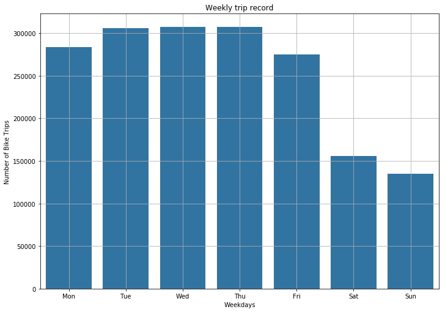

```python
plt.figure(figsize=[ 11.69, 8.27])
weekday = ['Mon', 'Tue', 'Wed', 'Thu', 'Fri', 'Sat', 'Sun']
sb.countplot(data=ford_df_clean,x='start_time_weekday',color=base_color,order=weekday);
plt.xlabel("Weekdays")
plt.ylabel("Number of Bike Trips")
plt.title('Weekly trip record');
plt.grid(True)
```

### During what time of the day bike rides are recorded most

The maximum percentage of trips occurs during peak(working) hours of 8am and also at around 5pm Could be because that's when people get to and back from the work.Its a bimodal distribution

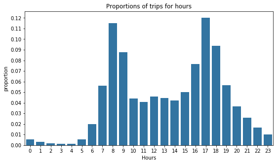

```python
# hourly usage of the bike sharing systems
plt.figure(figsize=[ 11.69, 8.27])
sb.countplot(data=ford_df_clean,x='start_time_hour',color=base_color)
plt.yticks(tick_props*n_points,tick_names)
plt.ylabel('proportion')
plt.xlabel('Hours');
plt.title("Proportions of trips for hours");
```

### What percentage of users are Male,Female and Others

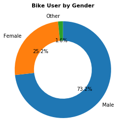

```python
plt.pie(gender,labels=gender.index, autopct='%1.1f%%',startangle=90,counterclock=False,wedgeprops={'width':0.4});
plt.axis('square');
plt.title('Bike User by Gender', y=1.05, fontsize=11, fontweight='bold');
plt.figure(figsize=[ 11.69, 8.27]);
```

### Illustrate the proportions of Users based on Subscription type

The Majority of the Bike Users are subscribers. Users with a monthly membership ("Subscriber type") make 88% of all customers in FY 2018 that used the system. 12% were casual riders ("Customer type") using the bike share system ocasionally.

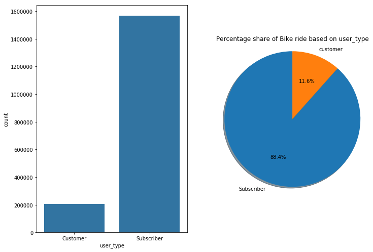

```python
plt.figure(figsize=[ 11.69, 8.27])
plt.subplot(1,2,1)
sb.countplot(data = ford_df_clean, x = 'user_type', color = base_color);

plt.subplot(1,2,2);

labels = ['Subscriber', 'customer']
plt.pie(ford_df_clean.user_type.value_counts(), autopct='%1.1f%%',labels=labels, shadow=True, startangle=90);

plt.axis('square');
plt.title("Percentage share of Bike ride based on user_type");
```

### Depict the proportions of User type based on Gender

The majority of Subscribers are Male with thrice the number of Female Subscribers.The same trend is seen in the customer riders as well.Suggesting irrespective of User_type, Male bikers are more than Female bikers and others.

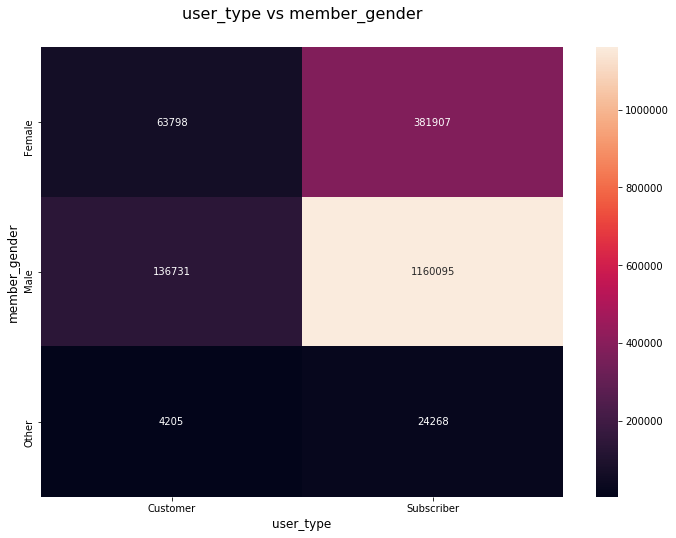

```python
plt.figure(figsize=[ 11.69, 8.27])
sb.heatmap(visu,annot=True,fmt='d');
plt.title('user_type vs member_gender',fontsize=16,y=1.05);
plt.xlabel('user_type',fontsize=12)
plt.ylabel('member_gender',fontsize=12);
```

### Represent the length of Duration per User type

There is a difference in the trip duration between customers and subscribers. Customers typically have trip durations are longer than for subscribers.This can probably be explained by the fact that subscribers are mainly commuters who take short trips to work/school rather than longer trips around the Bay Area.

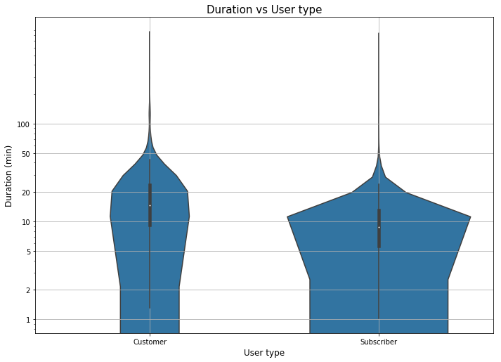

```python
plt.figure(figsize=[ 11.69, 8.27])
sb.violinplot(data = samp, x = 'user_type', y = 'duration_min',color=base_color);
plt.xlabel('User type',fontsize=12);
plt.yscale('log');
plt.yticks([1, 2, 5, 10, 20, 50, 100], [1, 2, 5, 10, 20, 50, 100]);
plt.ylabel('Duration (min)',fontsize=12);
plt.title("Duration vs User type",fontsize=15);
plt.grid(True)
```

#### What are the Weekdays Trends by User Type

There is a sharp contrast between Customers and Subscribers. Customers have a relatively low usage of the bike share system with a small increase on the weekends, indicates majority of customers are non-working crowd .On the contrary,Subscribers have steadily high usage on weekdays, with a sharp decline on the weekends.

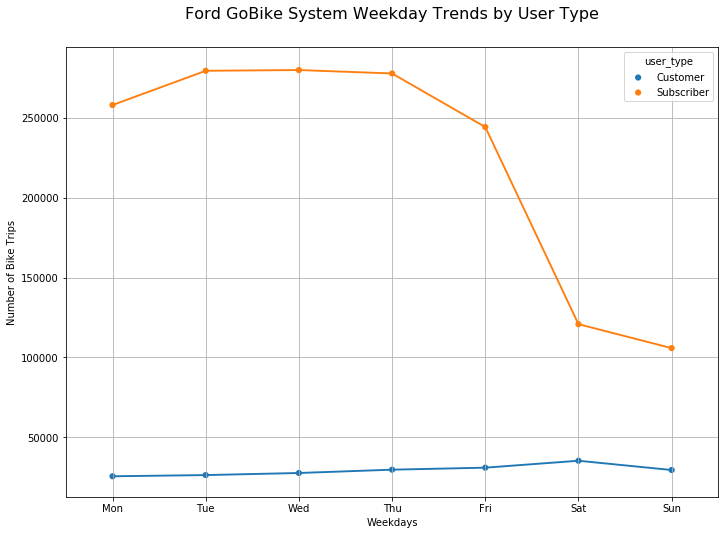

```python
# Customer Usage by Weekday vs. Subscriber Usage by Weekday
plt.figure(figsize=[ 11.69, 8.27])
ford_df_clean_user_week = ford_df_clean.groupby(['start_time_weekday', 'user_type']).size().reset_index()
weekday = ['Mon', 'Tue', 'Wed', 'Thu', 'Fri', 'Sat', 'Sun']

ax = sb.pointplot(data=ford_df_clean_user_week, x='start_time_weekday', y=0, hue = 'user_type', scale=.7, order = weekday);

plt.title('Ford GoBike System Weekday Trends by User Type', y=1.05, fontsize=16)
plt.xlabel('Weekdays')
plt.ylabel('Number of Bike Trips');
plt.grid()
```

### Relationship between Duration_min, User_type for different age_groups and member_gender

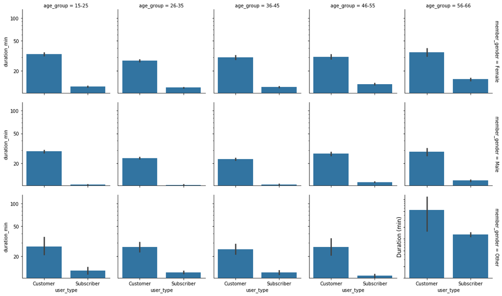

```python
g=sb.FacetGrid(data=ford_df_clean,col='age_group',row='member_gender',margin_titles=True);
g.map(sb.barplot,'user_type','duration_min');
plt.yscale('log')
plt.yticks([1, 2, 5, 10, 20, 50, 100], [1, 2, 5, 10, 20, 50, 100]);
plt.ylabel('Duration (min)',fontsize=12);
#plt.title("Duration vs User type",fontsize=15);
```

### Explore Daily and weekly usage by User types

**Customers use the bike sharing system more often on weekends:**

weekdays: most bike rides happen around 8-9am and 5-6pm with the peak on Fridays around 5pm

weekends: most bike rides happen between 10am - 8pm with the peak on Saturdays around 2pm

**Subscribers use the bike sharing system mainly on weekdays:**

weekdays: most bike rides happen around 8-9am and 5-6pm with the peak on Tuesdays around 8am

weekends: bikes are still rented but there is a significant drop in numbers of rented bikes throughout the entire weekends

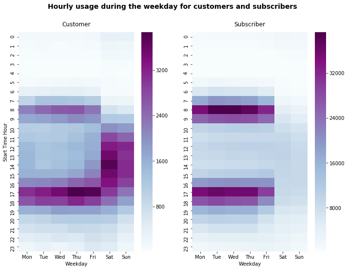

```python
# Setting the weekday order
ford_df_clean['start_time_weekday'] = pd.Categorical(ford_df_clean['start_time_weekday'],
                                                categories=['Mon','Tue','Wed','Thu','Fri','Sat', 'Sun'],
                                                ordered=True)
plt.figure(figsize=[ 11.69, 8.27])
plt.suptitle('Hourly usage during the weekday for customers and subscribers', fontsize=14, fontweight='semibold')

# heatmap for customers
plt.subplot(1, 2, 1)
df_customer = ford_df_clean.query('user_type == "Customer"').groupby(["start_time_hour", "start_time_weekday"])["bike_id"].size().reset_index()
df_customer = df_customer.pivot("start_time_hour", "start_time_weekday", "bike_id")
sb.heatmap(df_customer,cmap="BuPu")

plt.title("Customer", y=1.015)
plt.xlabel('Weekday')
plt.ylabel('Start Time Hour')

# heatmap for subscribers
plt.subplot(1, 2, 2)
df_subscriber = ford_df_clean.query('user_type == "Subscriber"').groupby(["start_time_hour", "start_time_weekday"])["bike_id"].size().reset_index()
df_subscriber = df_subscriber.pivot("start_time_hour", "start_time_weekday", "bike_id")
sb.heatmap(df_subscriber,cmap="BuPu")
plt.title("Subscriber", y=1.015)
plt.xlabel('Weekday')
plt.ylabel('');
```

### Summary

Renting bikes are done by two types of clients :**subscribers** who are mainly daily commuters, having short trips to and from work, who rent a bike on weekdays at 8-9am and 5-6pm, and, occasionally around the lunch time, and **customers**, usually tourists or occassional riders who use the system mainly on weekends to explore the Bay Area. With regard to Gender and age group ,Long trips are made by Females and older aged people.